# Multifactorial Assesment of Economic Data

Rohan Thorat - 50557738, Amulya Reddy Datla - 50560100, Chaitali Thakkar- 50557808, Jagruthi Reddy Ghanapat - 50560478

2024-05-18

# 1. Introduction

The dataset `FinalDataSet.csv` contains the following columns: - Year - State - StateMinimumWage - FederalMinimumWage - EffectiveMinimumWage - EffectiveMinimumWage2020Dollars - CPIAverage - FedFundsRate - Gdp - HomePriceIndex - MortgageRate - PopulationGrowth - UnemploymentRate

# 2. Data Reading

```r
library(readr)
data <- read_csv("FinalDataSet.csv")
head(data)
```

```
## # A tibble: 6 × 13
##    Year State      StateMinimumWage FederalMinimumWage EffectiveMinimumWage
##   <dbl> <chr>                 <dbl>              <dbl>                <dbl>
## 1  1968 Alabama               0                   1.15                 1.15
## 2  1968 Alaska                2.1                 1.15                 2.1
## 3  1968 Arizona               0.468               1.15                 1.15
## 4  1968 Arkansas              0.156               1.15                 1.15
## 5  1968 California            1.65                1.15                 1.65
## 6  1968 Colorado              1                   1.15                 1.15
## # ℹ 8 more variables: EffectiveMinimumWage2020Dollars <dbl>, CPIAverage <dbl>,
## #   FedFundsRate <dbl>, Gdp <dbl>, HomePriceIndex <dbl>, MortgageRate <dbl>,
## #   PopulationGrowth <dbl>, UnemploymentRate <dbl>
```

# 3. Data Cleaning

```r
# Impute missing values with mean
data[is.na(data)] <- mean(data, na.rm=TRUE)
# Remove duplicates
data <- unique(data)

# Check for missing values
sum(is.na(data))
```

```
## [1] 1188
```

# 4. Exploratory Data Analysis

Display the summary statistics of the dataset.  
Display the Corelation matrix.  
Identify the top 3 variables that are most correlated with EffectiveMinimumWage.

```r
summary(data)
```

```
##       Year         State           StateMinimumWage FederalMinimumWage
##  Min.   :1968   Length:2862        Min.   : 0.000   Min.   :1.150
##  1st Qu.:1981   Class :character   1st Qu.: 1.600   1st Qu.:3.350
##  Median :1994   Mode  :character   Median : 3.350   Median :4.250
##  Mean   :1994                      Mean   : 3.754   Mean   :4.356
##  3rd Qu.:2007                      3rd Qu.: 5.150   3rd Qu.:5.150
##  Max.   :2020                      Max.   :14.000   Max.   :7.250
##
##  EffectiveMinimumWage EffectiveMinimumWage2020Dollars   CPIAverage
##  Min.   : 1.150       Min.   : 6.420                  Min.   : 34.8
##  1st Qu.: 3.350       1st Qu.: 7.610                  1st Qu.: 90.9
##  Median : 4.250       Median : 8.170                  Median :148.2
##  Mean   : 4.624       Mean   : 8.361                  Mean   :145.4
##  3rd Qu.: 6.550       3rd Qu.: 8.980                  3rd Qu.:207.3
##  Max.   :14.000       Max.   :15.610                  Max.   :258.7
##
##   FedFundsRate           Gdp          HomePriceIndex    MortgageRate
##  Min.   : 0.08917   Min.   :  940.6   Min.   : 66.25   Min.   : 3.112
##  1st Qu.: 1.83167   1st Qu.: 3207.0   1st Qu.: 80.99   1st Qu.: 5.827
##  Median : 5.04500   Median : 7287.2   Median :136.50   Median : 7.570
##  Mean   : 5.13335   Mean   : 8758.2   Mean   :130.28   Mean   : 7.898
##  3rd Qu.: 7.56833   3rd Qu.:14474.2   3rd Qu.:171.74   3rd Qu.: 9.642
##  Max.   :16.37833   Max.   :21521.4   Max.   :222.15   Max.   :16.642
##                                       NA's   :1026     NA's   :162
##  PopulationGrowth UnemploymentRate
##  Min.   :0.4554   Min.   :3.492
##  1st Qu.:0.8861   1st Qu.:4.942
##  Median :0.9533   Median :5.800
##  Mean   :0.9657   Mean   :6.138
##  3rd Qu.:1.1036   3rd Qu.:7.192
##  Max.   :1.3869   Max.   :9.708
##
```

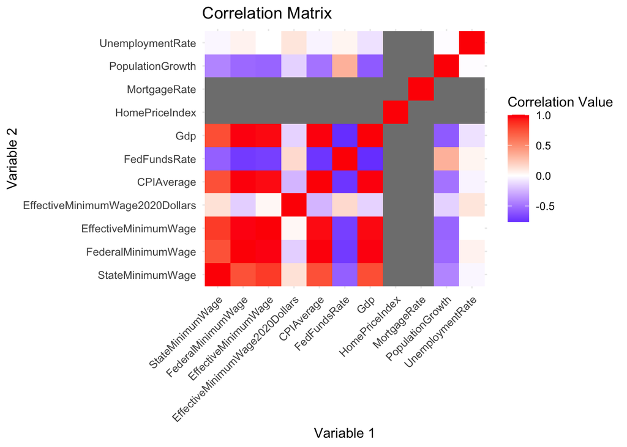

```r
library(ggplot2)
library(reshape2)

correlation_matrix <- cor(data[, -c(1, 2)])
melted_correlation <- melt(correlation_matrix)

ggplot(data = melted_correlation, aes(x=Var1, y=Var2, fill=value)) +
  geom_tile() +
  scale_fill_gradient2(low="blue", high="red", mid="white", midpoint=0) +
  theme_minimal() +
  theme(axis.text.x = element_text(angle = 45, hjust = 1)) +
  labs(title="Correlation Matrix", x="Variable 1", y="Variable 2", fill="Correlation Value")
```

```r
correlation_values <- correlation_matrix["EffectiveMinimumWage", ]
top_correlated_variables <- names(sort(correlation_values, decreasing=TRUE)[2:4])
top_correlated_variables
```

```
## [1] "FederalMinimumWage" "Gdp"                "CPIAverage"
```

# 5. Data Modelling

Split the data into training and testing sets for modeling

```r
library(caret)
trainIndex <- createDataPartition(data$EffectiveMinimumWage, p = .8,
                                  list = FALSE,
                                  times = 1)
train <- data[ trainIndex,]
test  <- data[-trainIndex,]

# Remove rows with missing values in the training and testing sets
train <- train[complete.cases(train), ]
test <- test[complete.cases(test), ]
dim(train)
```

```
## [1] 1477   13
```

```r
dim(test)
```

```
## [1] 359  13
```

# 6. Model Building

### 6.1 Base Linear Regression Model

Train a basemodel linear regression model to predict EffectiveMinimumWage using all other variables

```r
base_model <- lm(EffectiveMinimumWage ~ ., data = train)

# mse for thw base model

predictions <- predict(base_model, test)
base_model_mse <- mean((test$EffectiveMinimumWage - predictions)^2)
base_model_mse
```

```
## [1] 0.01270114
```

With the base model now trained we can try to analyze the model to figure out various ways to improve.

Check for Multi-collinearity in the model using Variance Inflation Factor (VIF)

```r
library(car)
vif(base_model)
```

```
##                                        GVIF Df GVIF^(1/(2*Df))
## Year                            1079.725412  1       32.859175
## State                              7.964466 53        1.019768
## StateMinimumWage                  10.158828  1        3.187292
## FederalMinimumWage                89.790812  1        9.475801
## EffectiveMinimumWage2020Dollars    4.342244  1        2.083805
## CPIAverage                       476.683068  1       21.833073
## FedFundsRate                      11.830189  1        3.439504
## Gdp                              258.139198  1       16.066711
## HomePriceIndex                    45.319178  1        6.731952
## MortgageRate                      53.613775  1        7.322143
## PopulationGrowth                   3.679491  1        1.918200
## UnemploymentRate                   2.715443  1        1.647860
```

Since the columns FederalMinimumWage and StateMinimumWage are just engineered features of the EffectiveMinimumWage, we can remove them from the model.

The columns CPIAverage and Gdp even though they have high VIF values, they are important features extracted from different datasets and hence we will keep them in the model.

Drop the columns FederalMinimumWage and StateMinimumWage from the model and retrain the model.

```r
train <- train[, -c(3, 4)]
test <- test[, -c(3, 4)]

head(train)
```

```
## # A tibble: 6 × 11
##    Year State       EffectiveMinimumWage EffectiveMinimumWage2020Do…¹ CPIAverage
##   <dbl> <chr>                      <dbl>                        <dbl>      <dbl>
## 1  1987 Alabama                     3.35                         7.63       114.
## 2  1987 Alaska                      3.85                         8.77       114.
## 3  1987 Arizona                     3.35                         7.63       114.
## 4  1987 Arkansas                    3.35                         7.63       114.
## 5  1987 Colorado                    3.35                         7.63       114.
## 6  1987 Connecticut                 3.37                         7.67       114.
## # ℹ abbreviated name: ¹EffectiveMinimumWage2020Dollars
## # ℹ 6 more variables: FedFundsRate <dbl>, Gdp <dbl>, HomePriceIndex <dbl>,
## #   MortgageRate <dbl>, PopulationGrowth <dbl>, UnemploymentRate <dbl>
```

```r
head(test)
```

```
## # A tibble: 6 × 11
##    Year State          EffectiveMinimumWage EffectiveMinimumWage202…¹ CPIAverage
##   <dbl> <chr>                         <dbl>                     <dbl>      <dbl>
## 1  1987 California                     3.35                      7.63       114.
## 2  1987 Guam                           3.35                      7.63       114.
## 3  1987 Idaho                          3.35                      7.63       114.
## 4  1987 Michigan                       3.35                      7.63       114.
## 5  1987 Missouri                       3.35                      7.63       114.
## 6  1987 North Carolina                 3.35                      7.63       114.
## # ℹ abbreviated name: ¹EffectiveMinimumWage2020Dollars
## # ℹ 6 more variables: FedFundsRate <dbl>, Gdp <dbl>, HomePriceIndex <dbl>,
## #   MortgageRate <dbl>, PopulationGrowth <dbl>, UnemploymentRate <dbl>
```

```r
model <- lm(EffectiveMinimumWage ~ ., data = train)
```

Calculate the Mean Squared Error (MSE) of the model on the test set and display the model summary

```r
predictions <- predict(model, test)
mse <- mean((test$EffectiveMinimumWage - predictions)^2)
summary(model)
```

```
##
## Call:
## lm(formula = EffectiveMinimumWage ~ ., data = train)
##
## Residuals:
##      Min       1Q   Median       3Q      Max
## -0.49749 -0.07205 -0.00469  0.07568  0.55829
##
## Coefficients:
##                                   Estimate Std. Error t value Pr(>|t|)
## (Intercept)                      6.506e+01  1.957e+01   3.324 0.000910 ***
## Year                            -3.638e-02  9.909e-03  -3.671 0.000250 ***
## StateAlaska                     -1.782e-01  3.330e-02  -5.352 1.02e-07 ***
## StateArizona                     1.712e-02  3.350e-02   0.511 0.609358
## StateArkansas                    9.344e-03  3.359e-02   0.278 0.780912
## StateCalifornia                 -3.059e-02  3.499e-02  -0.874 0.382178
## StateColorado                    2.850e-02  3.344e-02   0.852 0.394138
## StateConnecticut                -1.418e-01  3.418e-02  -4.149 3.54e-05 ***
## StateDelaware                   -4.791e-02  3.369e-02  -1.422 0.155176
## StateDistrict of Columbia       -4.859e-02  3.558e-02  -1.366 0.172301
## StateFlorida                    -1.508e-02  3.307e-02  -0.456 0.648316
## StateGeorgia                    -1.306e-02  3.300e-02  -0.396 0.692385
## StateGuam                        2.556e-03  3.492e-02   0.073 0.941646
## StateHawaii                     -1.238e-01  3.491e-02  -3.545 0.000406 ***
## StateIdaho                      -1.262e-02  3.355e-02  -0.376 0.706804
## StateIllinois                   -1.179e-02  3.437e-02  -0.343 0.731600
## StateIndiana                    -1.903e-02  3.385e-02  -0.562 0.574112
## StateIowa                       -5.390e-02  3.251e-02  -1.658 0.097585 .
## StateKansas                     -2.409e-02  3.328e-02  -0.724 0.469338
## StateKentucky                   -1.655e-03  3.327e-02  -0.050 0.960337
## StateLouisiana                  -1.835e-03  3.387e-02  -0.054 0.956809
## StateMaine                      -3.391e-02  3.452e-02  -0.982 0.326211
## StateMaryland                    2.690e-02  3.334e-02   0.807 0.419851
## StateMassachusetts              -8.809e-02  3.386e-02  -2.601 0.009379 **
## StateMichigan                    1.693e-03  3.430e-02   0.049 0.960646
## StateMinnesota                  -4.920e-02  3.419e-02  -1.439 0.150441
## StateMississippi                -1.281e-02  3.355e-02  -0.382 0.702690
## StateMissouri                    9.925e-03  3.331e-02   0.298 0.765770
## StateMontana                     2.515e-03  3.358e-02   0.075 0.940315
## StateNebraska                    5.017e-03  3.359e-02   0.149 0.881269
```

[output cut: 24 more lines]

```
## StateWyoming                    -2.055e-02  3.300e-02  -0.623 0.533599
## EffectiveMinimumWage2020Dollars  8.903e-01  4.943e-03 180.093  < 2e-16 ***
## CPIAverage                       2.918e-02  1.614e-03  18.075  < 2e-16 ***
## FedFundsRate                     2.416e-02  4.175e-03   5.788 8.78e-09 ***
## Gdp                              7.645e-05  1.022e-05   7.478 1.31e-13 ***
## HomePriceIndex                   5.222e-04  2.603e-04   2.006 0.045033 *
## MortgageRate                    -1.385e-03  1.104e-02  -0.126 0.900145
## PopulationGrowth                -6.117e-02  2.634e-02  -2.322 0.020350 *
## UnemploymentRate                 2.042e-02  3.171e-03   6.439 1.65e-10 ***
## ---
## Signif. codes:  0 '***' 0.001 '**' 0.01 '*' 0.05 '.' 0.1 ' ' 1
##
## Residual standard error: 0.1243 on 1414 degrees of freedom
## Multiple R-squared:  0.9959, Adjusted R-squared:  0.9957
## F-statistic:  5481 on 62 and 1414 DF,  p-value: < 2.2e-16
```

```r
mse
```

```
## [1] 0.01547404
```

## 6.3 Random Forest Regression Model

```r
library(randomForest)
rf_model <- randomForest(EffectiveMinimumWage ~ ., data = train)
rf_predictions <- predict(rf_model, test)
rf_mse <- mean((test$EffectiveMinimumWage - rf_predictions)^2)
rf_mse
```

```
## [1] 0.04438364
```

## 6.4 Lasso and Ridge Regression

```r
library(glmnet)
x_train <- as.matrix(train[, -c(1, 2)])
y_train <- train$EffectiveMinimumWage
x_test <- as.matrix(test[, -c(1, 2)])
y_test <- test$EffectiveMinimumWage

lasso_model <- cv.glmnet(x_train, y_train, alpha = 1)
lasso_predictions <- predict(lasso_model, s = "lambda.min", newx = x_test)
lasso_mse <- mean((y_test - lasso_predictions)^2)
lasso_mse
```

```
## [1] 0.002743171
```

```r
ridge_model <- cv.glmnet(x_train, y_train, alpha = 0)
ridge_predictions <- predict(ridge_model, s = "lambda.min", newx = x_test)
ridge_mse <- mean((y_test - ridge_predictions)^2)
ridge_mse
```

```
## [1] 0.01412393
```

## 6.5 20 fold cross validation to find the best alpha value for lasso and ridge regression models

```r
lasso_cv_model <- cv.glmnet(x_train, y_train, alpha = 1, nfolds = 20)
lasso_cv_alpha <- lasso_cv_model$lambda.min
lasso_cv_alpha
```

```
## [1] 0.05509429
```

```r
ridge_cv_model <- cv.glmnet(x_train, y_train, alpha = 0, nfolds = 20)
ridge_cv_alpha <- ridge_cv_model$lambda.min
ridge_cv_alpha
```

```
## [1] 0.1889993
```

```r
lasso_model <- cv.glmnet(x_train, y_train, alpha = 1, lambda = seq(0.001, 1, length = 100))
ridge_model <- cv.glmnet(x_train, y_train, alpha = 0, lambda = seq(0.001, 1, length = 100))

lasso_predictions <- predict(lasso_model, s = "lambda.min", newx = x_test)
lasso_mse <- mean((y_test - lasso_predictions)^2)
lasso_mse
```

```
## [1] 9.037319e-07
```

```r
ridge_predictions <- predict(ridge_model, s = "lambda.min", newx = x_test)
ridge_mse <- mean((y_test - ridge_predictions)^2)
ridge_mse
```

```
## [1] 0.0002534786
```

### 6.7 Compare the MSE values of the linear regression, random forest, lasso, and ridge models

```r
model_names <- c("Linear Regression", "Random Forest", "Lasso", "Ridge")
mse_values <- c(mse, rf_mse, lasso_mse, ridge_mse)
model_comparison <- data.frame(Model = model_names, MSE = mse_values)
model_comparison
```

```
##               Model          MSE
## 1 Linear Regression 1.547404e-02
## 2     Random Forest 4.438364e-02
## 3             Lasso 9.037319e-07
## 4             Ridge 2.534786e-04
```

# 7. BONUS : Time Series Analaysis and Forecasting

Since the data has year column we can use time series analysis to predict the EffectiveMinimumWage for the next few years

### 7.1 ARIMA Model

Fit an ARIMA model to predict EffectiveMinimumWage

Split data into training and testing sets with test set being last 20% of the data

```r
train_size <- floor(0.8 * nrow(data))
train <- data[1:train_size, ]
test <- data[(train_size + 1):nrow(data), ]
```

#### Fit an ARIMA model to the training data

```r
library(forecast)
arima_model <- auto.arima(train$EffectiveMinimumWage)
arima_model
```

```
## Series: train$EffectiveMinimumWage
## ARIMA(5,1,1) with drift
##
## Coefficients:
##           ar1     ar2     ar3      ar4     ar5      ma1   drift
##       -0.0674  0.2276  0.0420  -0.1541  0.0017  -0.9166  0.0027
## s.e.   0.0280  0.0265  0.0241   0.0242  0.0249   0.0187  0.0007
##
## sigma^2 = 0.1254:  log likelihood = -869.01
## AIC=1754.03   AICc=1754.09   BIC=1799.91
```

#### Predict the EffectiveMinimumWage for the test set

```r
arima_predictions <- forecast(arima_model, h = nrow(test))
```

#### Calculate the Mean Squared Error (MSE) of the ARIMA model on the test set

```r
arima_mse <- mean((test$EffectiveMinimumWage - arima_predictions$mean)^2)
arima_mse
```

```
## [1] 1.382558
```